# Part I - Analysis of San Francisco Bay Ford GoBike System

## by Matthew Olushola Odebunmi

## Introduction

> This data set includes information about individual rides made in a bike-sharing system covering the greater San Francisco Bay area.

> **The Dataset contains 16 Features:**
> 1. Time duration in seconds
> 2. Start time and date
> 3. End time and date
> 4. Start Station ID
> 5. Start Station Name
> 6. Start Station Latitude
> 7. Start Station Longitude
> 8. End Station ID
> 9. End Station Name
> 10. End Station Latitude
> 11. End station Longitude
> 12. Bike ID
> 13. User Type
> 14. Member Birth year
> 15. Member Gender
> 16. Bike Share for all Trip

## Preliminary Wrangling

> First i will check the dataset features, remove duplicates if any, remove null values, convert some datatype, drop some features that is/are not needed

```python
# import all packages and set plots to be embedded inline
import re
import datetime
import numpy as np
import pandas as pd
import matplotlib.pyplot as plt
import seaborn as sb

%matplotlib inline
```

```python
fordgobike = pd.read_csv('201902-fordgobike-tripdata.csv')
```

```python
fordgobike.head(5)
```

|  | duration_sec | start_time | end_time | start_station_id | start_station_name | start_station_latitude | start_station_longitude | end_station_id | end_station_name | end_station_latitude | end_station_longitude | bike_id | user_type | member_birth_year | member_gender | bike_share_for_all_trip |
| --- | --- | --- | --- | --- | --- | --- | --- | --- | --- | --- | --- | --- | --- | --- | --- | --- |
| 0 | 52185 | 2019-02-28 17:32:10.1450 | 2019-03-01 08:01:55.9750 | 21.0 | Montgomery St BART Station (Market St at 2nd St) | 37.789625 | -122.400811 | 13.0 | Commercial St at Montgomery St | 37.794231 | -122.402923 | 4902 | Customer | 1984.0 | Male | No |
| 1 | 42521 | 2019-02-28 18:53:21.7890 | 2019-03-01 06:42:03.0560 | 23.0 | The Embarcadero at Steuart St | 37.791464 | -122.391034 | 81.0 | Berry St at 4th St | 37.775880 | -122.393170 | 2535 | Customer | NaN | NaN | No |
| 2 | 61854 | 2019-02-28 12:13:13.2180 | 2019-03-01 05:24:08.1460 | 86.0 | Market St at Dolores St | 37.769305 | -122.426826 | 3.0 | Powell St BART Station (Market St at 4th St) | 37.786375 | -122.404904 | 5905 | Customer | 1972.0 | Male | No |
| 3 | 36490 | 2019-02-28 17:54:26.0100 | 2019-03-01 04:02:36.8420 | 375.0 | Grove St at Masonic Ave | 37.774836 | -122.446546 | 70.0 | Central Ave at Fell St | 37.773311 | -122.444293 | 6638 | Subscriber | 1989.0 | Other | No |
| 4 | 1585 | 2019-02-28 23:54:18.5490 | 2019-03-01 00:20:44.0740 | 7.0 | Frank H Ogawa Plaza | 37.804562 | -122.271738 | 222.0 | 10th Ave at E 15th St | 37.792714 | -122.248780 | 4898 | Subscriber | 1974.0 | Male | Yes |

```python
#Dataset Shape
fordgobike.shape
```

```
(183412, 16)
```

```python
fordgobike.info()
```

```
<class 'pandas.core.frame.DataFrame'>
RangeIndex: 183412 entries, 0 to 183411
Data columns (total 16 columns):
duration_sec               183412 non-null int64
start_time                 183412 non-null object
end_time                   183412 non-null object
start_station_id           183215 non-null float64
start_station_name         183215 non-null object
start_station_latitude     183412 non-null float64
start_station_longitude    183412 non-null float64
end_station_id             183215 non-null float64
end_station_name           183215 non-null object
end_station_latitude       183412 non-null float64
end_station_longitude      183412 non-null float64
bike_id                    183412 non-null int64
user_type                  183412 non-null object
member_birth_year          175147 non-null float64
member_gender              175147 non-null object
bike_share_for_all_trip    183412 non-null object
dtypes: float64(7), int64(2), object(7)
memory usage: 22.4+ MB
```

```python
#Check for duplicated
fordgobike.duplicated().sum()
```

```
0
```

```python
#check for null entries
fordgobike.isna().sum()
```

```
duration_sec                  0
start_time                    0
end_time                      0
start_station_id            197
start_station_name          197
start_station_latitude        0
start_station_longitude       0
end_station_id              197
end_station_name            197
end_station_latitude          0
end_station_longitude         0
bike_id                       0
user_type                     0
member_birth_year          8265
member_gender              8265
bike_share_for_all_trip       0
dtype: int64
```

```python
#Drop the null entries
fordgobike.dropna(inplace=True)
fordgobike.info()
```

```
<class 'pandas.core.frame.DataFrame'>
Int64Index: 174952 entries, 0 to 183411
Data columns (total 16 columns):
duration_sec               174952 non-null int64
start_time                 174952 non-null object
end_time                   174952 non-null object
start_station_id           174952 non-null float64
start_station_name         174952 non-null object
start_station_latitude     174952 non-null float64
start_station_longitude    174952 non-null float64
end_station_id             174952 non-null float64
end_station_name           174952 non-null object
end_station_latitude       174952 non-null float64
end_station_longitude      174952 non-null float64
bike_id                    174952 non-null int64
user_type                  174952 non-null object
member_birth_year          174952 non-null float64
member_gender              174952 non-null object
bike_share_for_all_trip    174952 non-null object
dtypes: float64(7), int64(2), object(7)
memory usage: 22.7+ MB
```

```python
# Convert start_time and end_time to datetime
fordgobike['start_time'] = pd.to_datetime(fordgobike['start_time'])
fordgobike['end_time'] = pd.to_datetime(fordgobike['end_time'])
```

```python
# Convert Memember Birth Year to Integer
fordgobike['member_birth_year'] = fordgobike['member_birth_year'].astype(int)
```

```python
# Drop some features that are not needed fo the analysis
drop_list = ['start_station_id','start_station_latitude','start_station_longitude','end_station_id','end_station_latitude',
            'end_station_longitude','bike_id']
```

```python
fordgobike.drop(drop_list, axis=1, inplace=True)
```

```python
fordgobike.info()
```

```
<class 'pandas.core.frame.DataFrame'>
Int64Index: 174952 entries, 0 to 183411
Data columns (total 9 columns):
duration_sec               174952 non-null int64
start_time                 174952 non-null datetime64[ns]
end_time                   174952 non-null datetime64[ns]
start_station_name         174952 non-null object
end_station_name           174952 non-null object
user_type                  174952 non-null object
member_birth_year          174952 non-null int64
member_gender              174952 non-null object
bike_share_for_all_trip    174952 non-null object
dtypes: datetime64[ns](2), int64(2), object(5)
memory usage: 13.3+ MB
```

### What is the structure of your dataset?

> The dataset consist of 174952 entries of trips by Ford GoBike Sanfrancisco Bay. The dataset has 16 Features,

### The Dataset contains 16 Features

> 1. Time duration in seconds
> 2. Start time and date
> 3. End time and date
> 4. Start Station ID
> 5. Start Station Name
> 6. Start Station Latitude
> 7. Start Station Longitude
> 8. End Station ID
> 9. End Station Name
> 10. End Station Latitude
> 11. End station Longitude
> 12. Bike ID
> 13. User Type
> 14. Member Birth year
> 15. Member Gender
> 16. Bike Share for all Trip

### What features in the dataset do you think will help support your investigation into your feature(s) of interest?

> **I am interested in the duration of the trips**
> 1. Time duration in seconds
> 2. Start time and date
> 3. End time and date
> 4. Start Station Name
> 5. End Station Name
> 6. user_type
> 7. Member Birth year
> 8. Member Gender
> 9. Bike Share for all Trip

## Univariate Exploration

```python
fordgobike.head(5)
```

|  | duration_sec | start_time | end_time | start_station_name | end_station_name | user_type | member_birth_year | member_gender | bike_share_for_all_trip |
| --- | --- | --- | --- | --- | --- | --- | --- | --- | --- |
| 0 | 52185 | 2019-02-28 17:32:10.145 | 2019-03-01 08:01:55.975 | Montgomery St BART Station (Market St at 2nd St) | Commercial St at Montgomery St | Customer | 1984 | Male | No |
| 2 | 61854 | 2019-02-28 12:13:13.218 | 2019-03-01 05:24:08.146 | Market St at Dolores St | Powell St BART Station (Market St at 4th St) | Customer | 1972 | Male | No |
| 3 | 36490 | 2019-02-28 17:54:26.010 | 2019-03-01 04:02:36.842 | Grove St at Masonic Ave | Central Ave at Fell St | Subscriber | 1989 | Other | No |
| 4 | 1585 | 2019-02-28 23:54:18.549 | 2019-03-01 00:20:44.074 | Frank H Ogawa Plaza | 10th Ave at E 15th St | Subscriber | 1974 | Male | Yes |
| 5 | 1793 | 2019-02-28 23:49:58.632 | 2019-03-01 00:19:51.760 | 4th St at Mission Bay Blvd S | Broadway at Kearny | Subscriber | 1959 | Male | No |

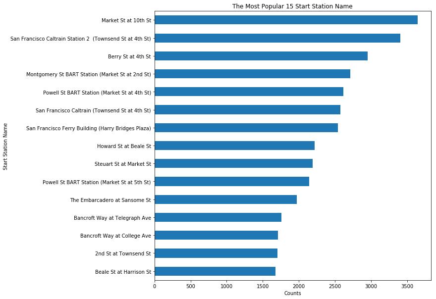

```python
# Most Popular Start Station Name

plt.figure(figsize = [10,10])
default_color = sb.color_palette()[0]
fordgobike.start_station_name.value_counts(ascending=True).tail(15).plot.barh(color=default_color);
plt.ylabel('Start Station Name')
plt.xlabel('Counts')
plt.title('The Most Popular 15 Start Station Name')

plt.show()
```

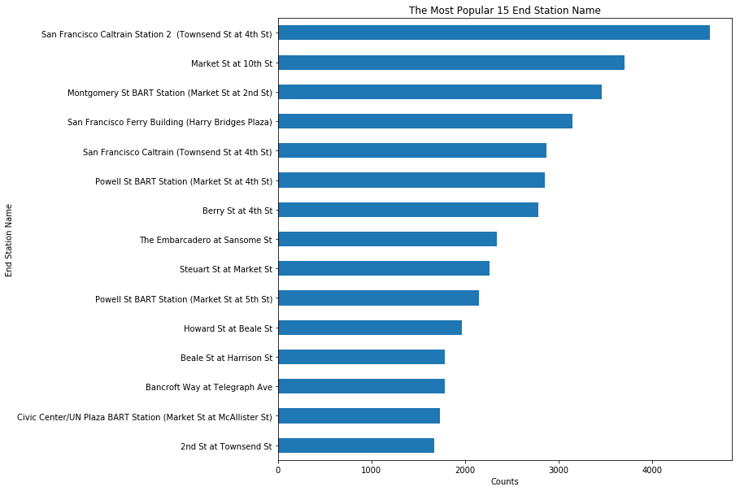

```python
# most Popular End Station Name
plt.figure(figsize = [10,10])
default_color = sb.color_palette()[0]
fordgobike.end_station_name.value_counts(ascending=True).tail(15).plot.barh(color=default_color);
plt.ylabel('End Station Name')
plt.xlabel('Counts')
plt.title('The Most Popular 15 End Station Name')

plt.show()
```

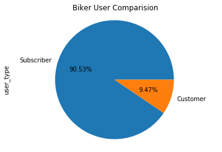

```python
# Bike User Comparison
fig, ax = figsize = [10,10]
fordgobike.user_type.value_counts().plot.pie(autopct='%1.2f%%')
plt.axis('equal');
plt.title(' Biker User Comparision');
```

> 90.53% that undergo the trips were Subscriber while only 9.47% were Customer

```python
def myCountPlot(df, xVar,color=default_color,order=None):

    # plot dimensions
    plt.figure(figsize=[14,6])
    #plot
    sb.countplot(data=df, x=xVar,edgecolor='black', color=color,order=order)
    xVar=xVar.replace("_", " ") #replace _ with space
    # Add title and format
    plt.title(f'''Distribution of {xVar}'''.title(), fontsize=14, weight="bold")
    # Add xlabel and format it
    plt.xlabel(xVar.title(), fontsize = 10, weight = "bold")
    # Add ylabel and format it
    plt.ylabel('Frequency'.title(), fontsize =10, weight ="bold" )
```

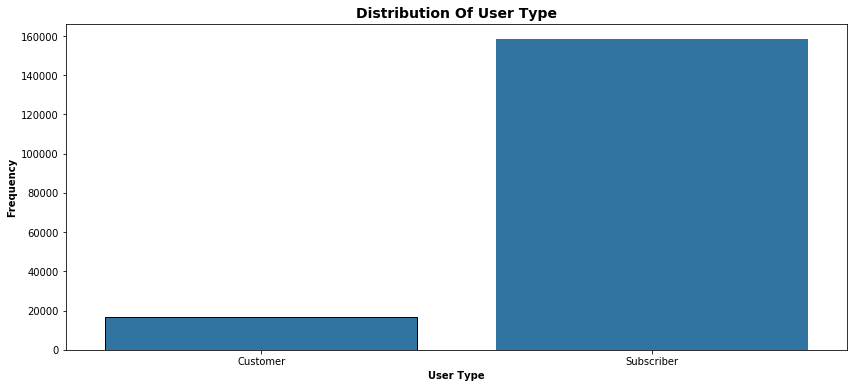

```python
# call plot function
myCountPlot(fordgobike, 'user_type')
```

> The bar chart shows the same insight as the pie chart above with the Bike subscriber over 9times the customer

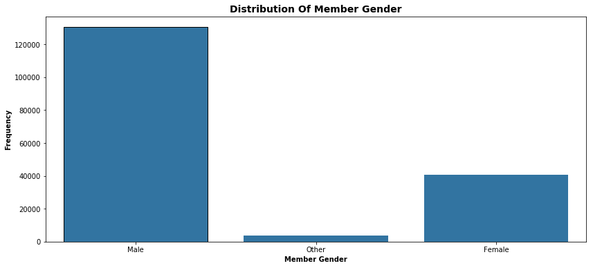

```python
# Distribution of the Gender
myCountPlot(fordgobike, 'member_gender')
```

> male users are most frequent

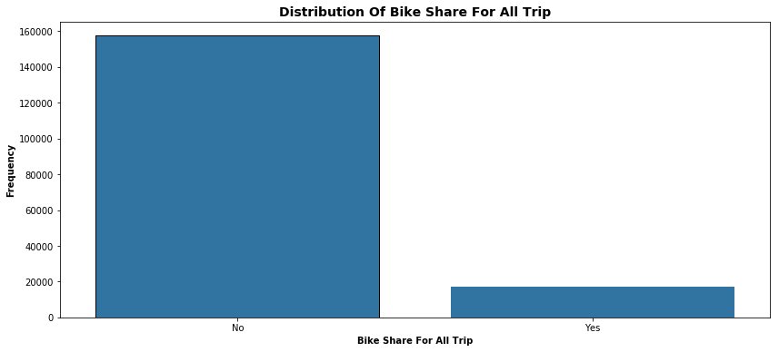

```python
# Distribution of Bike share for all trip
myCountPlot(fordgobike, 'bike_share_for_all_trip')
```

> Most Bike user do not share their trip

```python
from datetime import time
```

```python
#Create  new variables in the dataframe
fordgobike['start_day'] = fordgobike['start_time'].dt.day_name()
fordgobike['start_hour'] = fordgobike['start_time'].dt.hour
```

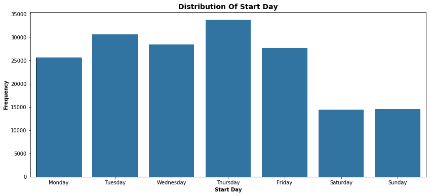

```python
# Distribution of Users across days of the week
day_of_wk = ['Monday', 'Tuesday','Wednesday','Thursday','Friday','Saturday','Sunday']
myCountPlot(fordgobike, 'start_day', order=day_of_wk)
```

> The most active day to the start trip is Thurday

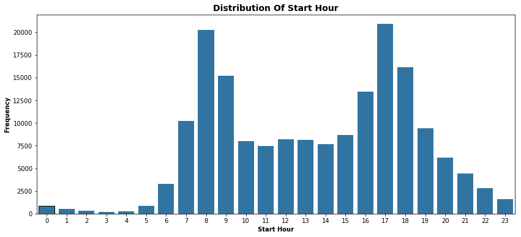

```python
# Distribution of Start hour rate for the trip
myCountPlot(fordgobike,'start_hour')
```

> The distribution of the start time chart show 2 peak of 8 hour and 17 hour

```python
fordgobike.describe()
```

|  | duration_sec | member_birth_year | start_hour |
| --- | --- | --- | --- |
| count | 174952.000000 | 174952.000000 | 174952.000000 |
| mean | 704.002744 | 1984.803135 | 13.456165 |
| std | 1642.204905 | 10.118731 | 4.734282 |
| min | 61.000000 | 1878.000000 | 0.000000 |
| 25% | 323.000000 | 1980.000000 | 9.000000 |
| 50% | 510.000000 | 1987.000000 | 14.000000 |
| 75% | 789.000000 | 1992.000000 | 17.000000 |
| max | 84548.000000 | 2001.000000 | 23.000000 |

```python
fordgobike['duration_sec'].min(), fordgobike['duration_sec'].max()
```

```
(61, 84548)
```

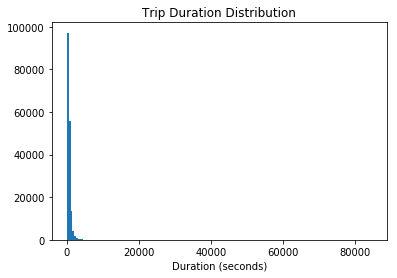

```python
# Trip Distribution Duration

binsize = 500
bins = np.arange(61, fordgobike['duration_sec'].max()+binsize, binsize)
plt.hist(data=fordgobike, x='duration_sec', bins=bins)
plt.xlabel('Duration (seconds)')
plt.title('Trip Duration Distribution')
plt.show()
```

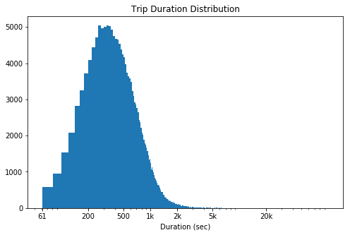

```python
# Trip Duration Distribution using log scale


bins = np.arange(61, 1e5, 20)

plt.figure(figsize=[8,5])
plt.hist(data=fordgobike, x='duration_sec', bins = bins)
plt.xscale('log')
plt.xticks([61,200,500,1e3,2e3,5e3,20e3],[61,200, 500, '1k', '2k', '5k', '20k'])
plt.xlabel('Duration (sec)')
plt.title('Trip Duration Distribution');
```

### Discuss the distribution(s) of your variable(s) of interest. Were there any unusual points? Did you need to perform any transformations?

> The curve of the duration is skewed right, I performed logarithms scale transformation. The curve peak is at 300 sec

### Of the features you investigated, were there any unusual distributions? Did you perform any operations on the data to tidy, adjust, or change the form of the data? If so, why did you do this?

> There are 2 peaks at the start time of 8am and 5pm for the Users. I tidy and change the format of the Start time and end time to fit datetime.

> Most biker user start their trip on thursday

> Most biker are Male and do not share their trip

## Bivariate Exploration

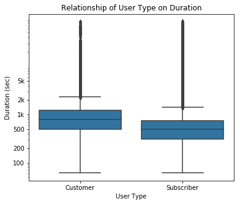

```python
plt.figure(figsize=[6,5])
sb.boxplot(data=fordgobike,x='user_type', y='duration_sec', color=default_color)
plt.yscale('log')
plt.yticks([100,200,500,1e3,2e3,5e3],[100,200,500,'1k','2k','5k'])
plt.xlabel('User Type')
plt.ylabel('Duration (sec)')
plt.title('Relationship of User Type on Duration')
plt.show()
```

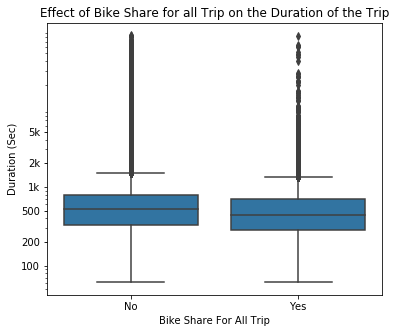

```python
plt.figure(figsize=[6,5])
sb.boxplot(data=fordgobike,x='bike_share_for_all_trip',y='duration_sec',color=default_color)
plt.yscale('log')
plt.yticks([100,200,500,1e3,2e3,5e3],[100,200,500,'1k','2k','5k'])
plt.xlabel('Bike Share For All Trip')
plt.ylabel('Duration (Sec)')
plt.title('Effect of Bike Share for all Trip on the Duration of the Trip');
```

> From the boxplot, the longer the trip(duration), Biker do not share their trip

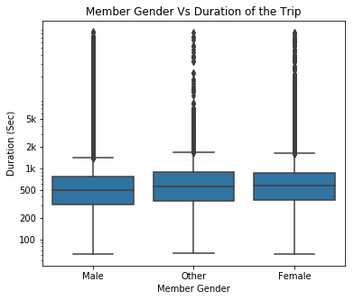

```python
plt.figure(figsize=[6,5])
sb.boxplot(data=fordgobike,x='member_gender',y='duration_sec',color=default_color)
plt.yscale('log')
plt.yticks([100,200,500,1e3,2e3,5e3],[100,200,500,'1k','2k','5k'])
plt.xlabel('Member Gender')
plt.ylabel('Duration (Sec)')
plt.title('Member Gender Vs Duration of the Trip');
```

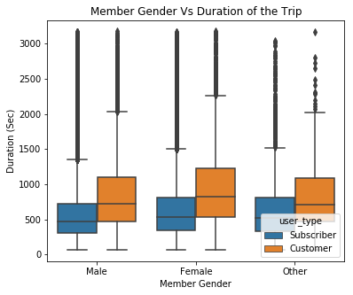

```python
plt.figure(figsize=[6,5])
sb.boxplot(data=fordgobike.query('duration_sec<duration_sec.quantile(0.99)'),
           x='member_gender',y='duration_sec',hue='user_type')
plt.xlabel('Member Gender')
plt.ylabel('Duration (Sec)')
plt.title('Member Gender Vs Duration of the Trip');
```

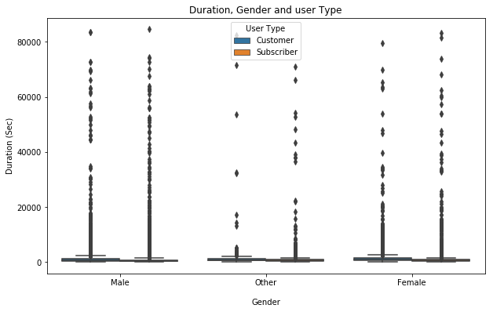

```python
plt.figure(figsize=[10,6])
sb.boxplot(data=fordgobike, x='member_gender',y='duration_sec',hue='user_type')
plt.xlabel('Gender', labelpad=15)
plt.ylabel('Duration (Sec)')
plt.title('Duration, Gender and user Type')
plt.legend(title='User Type');
```

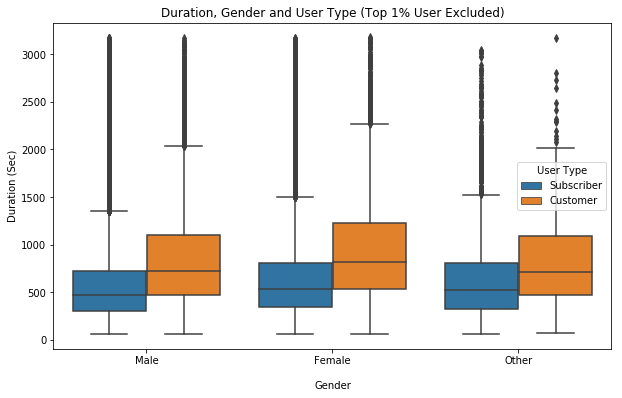

```python
plt.figure(figsize=[10,6])
sb.boxplot(data=fordgobike.query('duration_sec<duration_sec.quantile(0.99)'),
           x='member_gender',y='duration_sec',hue='user_type')
plt.xlabel('Gender', labelpad=15)
plt.ylabel('Duration (Sec)')
plt.title('Duration, Gender and User Type (Top 1% User Excluded)')
plt.legend(title='User Type');
```

> Male User Subscriber have shorter Trip

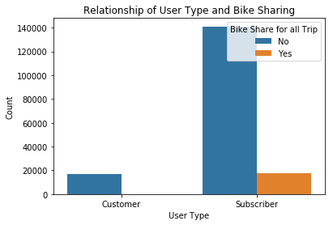

```python
sb.countplot(data=fordgobike,x='user_type',hue='bike_share_for_all_trip')
plt.xlabel('User Type')
plt.ylabel('Count')
plt.legend(title='Bike Share for all Trip')
plt.title('Relationship of User Type and Bike Sharing');
```

> It clearly that only Subscriber Users share their trip

### Talk about some of the relationships you observed in this part of the investigation. How did the feature(s) of interest vary with other features in the dataset?

> The longer the duration of the trip, biker do not share the trip

> Customer has longer trip

> male user have shorter trip

### Did you observe any interesting relationships between the other features (not the main feature(s) of interest)?

> Only the Subscriber Users Share their trip

## Multivariate Exploration

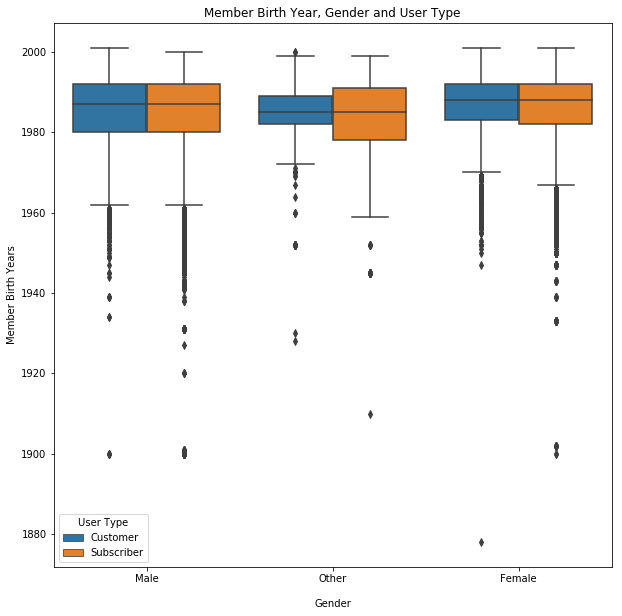

```python
plt.figure(figsize=[10,10])
sb.boxplot(data=fordgobike,x='member_gender',y='member_birth_year',hue='user_type')
plt.xlabel('Gender', labelpad=15)
plt.ylabel('Member Birth Years')
plt.title('Member Birth Year, Gender and User Type')
plt.legend(title='User Type');
```

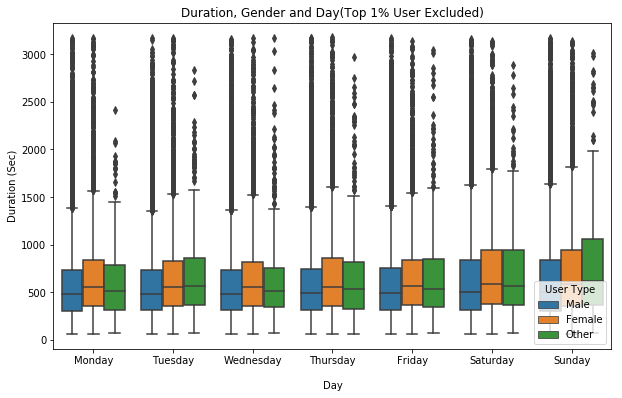

```python
#Relationships of Duration, Gender and Day in 2D visualization
plt.figure(figsize=[10,6])
sb.boxplot(data=fordgobike.query('duration_sec<duration_sec.quantile(0.99)'), order=day_of_wk,
           x='start_day',y='duration_sec',hue='member_gender')
plt.xlabel('Day', labelpad=15)
plt.ylabel('Duration (Sec)')
plt.title('Duration, Gender and Day(Top 1% User Excluded)')
plt.legend(title='User Type');
```

> 2D visualization showing distribution of Gender across the days of the week over the duration of trip in sec

### Were there any interesting or surprising interactions between features?

> No

## Conclusions

> From the Analysis of San Francisco Bay Ford GoBike System:
> 1. I convert the Start Time and DateEnd Time and Date into datetime format for proper analaysis
> 2. I remove null values
> 3. I remove some features that are not needed for the data exploration

> **From the insight:**

> we can see the most prominnent Start Staion Name and End Station name

> 90.53% that undergo the trips were Subscriber while only 9.47% were Customer

> Male User Subscriber have shorter Trip

> The most active day to the start trip is Thurday

> The distribution of the start time chart show 2 peak of 8 hour and 17 hour

> The longer the trip(duration), Biker do not share their trip

> It clearly that only Subscriber Users share their trip